# COMPSCIX 415.2 Homework 7

Emerson Sosa

3/12/2019

# Exercise 1

*Load the train.csv dataset into R. How many observations and columns are there?*

There are 1460 observations and 81 variables/columns.

```r
train.data <-
  read_csv('train.csv')
glimpse(train.data)
```

```
## Observations: 1,460
## Variables: 81
## $ Id            <dbl> 1, 2, 3, 4, 5, 6, 7, 8, 9, 10, 11, 12, 13, 14, 15,…
## $ MSSubClass    <dbl> 60, 20, 60, 70, 60, 50, 20, 60, 50, 190, 20, 60, 2…
## $ MSZoning      <chr> "RL", "RL", "RL", "RL", "RL", "RL", "RL", "RL", "R…
## $ LotFrontage   <dbl> 65, 80, 68, 60, 84, 85, 75, NA, 51, 50, 70, 85, NA…
## $ LotArea       <dbl> 8450, 9600, 11250, 9550, 14260, 14115, 10084, 1038…
## $ Street        <chr> "Pave", "Pave", "Pave", "Pave", "Pave", "Pave", "P…
## $ Alley         <chr> NA, NA, NA, NA, NA, NA, NA, NA, NA, NA, NA, NA, NA…
## $ LotShape      <chr> "Reg", "Reg", "IR1", "IR1", "IR1", "IR1", "Reg", "…
## $ LandContour   <chr> "Lvl", "Lvl", "Lvl", "Lvl", "Lvl", "Lvl", "Lvl", "…
## $ Utilities     <chr> "AllPub", "AllPub", "AllPub", "AllPub", "AllPub", …
## $ LotConfig     <chr> "Inside", "FR2", "Inside", "Corner", "FR2", "Insid…
## $ LandSlope     <chr> "Gtl", "Gtl", "Gtl", "Gtl", "Gtl", "Gtl", "Gtl", "…
## $ Neighborhood  <chr> "CollgCr", "Veenker", "CollgCr", "Crawfor", "NoRid…
```

[output cut: 68 more lines]

# Exercise 2

*1. Visualize the distribution of SalePrice*

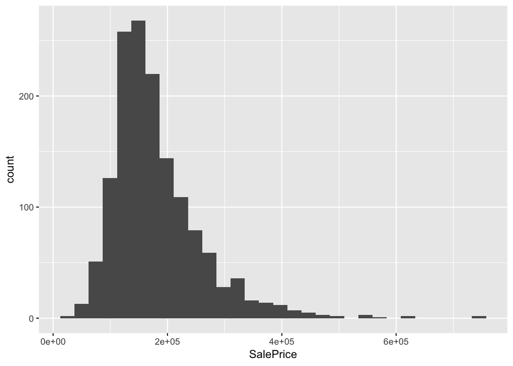

```r
train.data %>%
  ggplot() +
  geom_histogram(aes(SalePrice))
```

*2. Visualize the covariation between SalePrice and Neighborhood.*

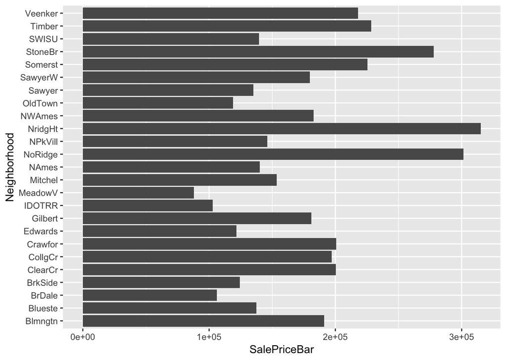

```r
hood.and.price <- train.data %>%
  group_by(Neighborhood) %>%
  summarise(SalePriceBar = median(SalePrice, na.rm = TRUE)) %>%
  arrange(desc(SalePriceBar))

ggplot(hood.and.price) +
  geom_col(aes(Neighborhood, SalePriceBar)) +
  coord_flip()
```

*3. Visualize the covariation between SalePrice and OverallQual.*

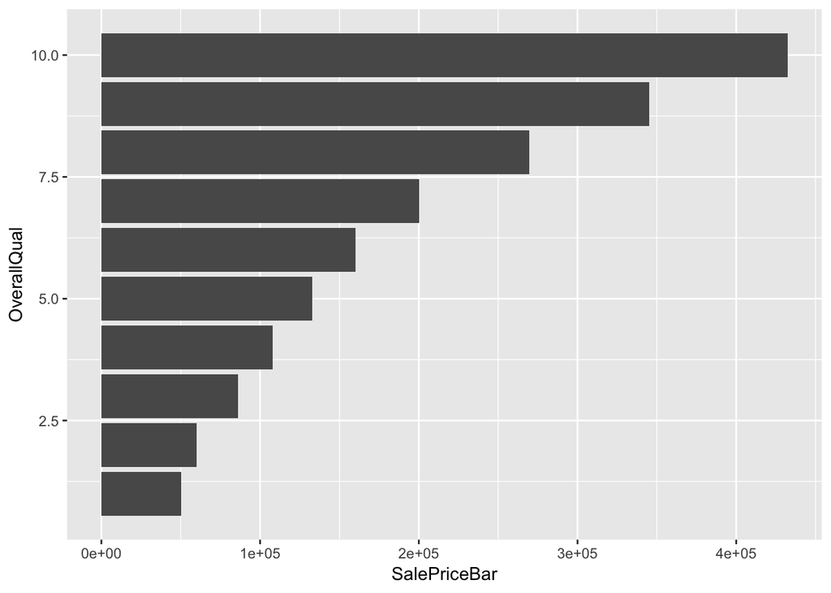

```r
qual.and.price <- train.data %>%
  group_by(OverallQual) %>%
  summarise(SalePriceBar = median(SalePrice, na.rm = TRUE))

ggplot(qual.and.price) +
  geom_col(aes(OverallQual, SalePriceBar)) +
  coord_flip()
```

# Exercise 3

*1. Take a look at the coefficient*

The coefficient is 45436 when using Overall Quality as `x`.

```r
(train.lm <- lm(formula = SalePrice ~ OverallQual, data = train.data))
```

```
##
## Call:
## lm(formula = SalePrice ~ OverallQual, data = train.data)
##
## Coefficients:
## (Intercept)  OverallQual
##      -96206        45436
```

```r
tidy(train.lm)
```

```
## # A tibble: 2 x 5
##   term        estimate std.error statistic   p.value
##   <chr>          <dbl>     <dbl>     <dbl>     <dbl>
## 1 (Intercept)  -96206.     5756.     -16.7 1.67e- 57
## 2 OverallQual   45436.      920.      49.4 2.19e-313
```

*2. Compare the coefficient to the average value of SalePrice*

The coefficient is much smaller than the mean of the SalePrice

```r
mean(train.data$SalePrice)
```

```
## [1] 180921.2
```

```r
train.lm
```

```
##
## Call:
## lm(formula = SalePrice ~ OverallQual, data = train.data)
##
## Coefficients:
## (Intercept)  OverallQual
##      -96206        45436
```

*3. Take a look at the R-squared*

The R squared is 0.63

```r
glance(train.lm)
```

```
## # A tibble: 1 x 11
##   r.squared adj.r.squared  sigma statistic   p.value    df  logLik    AIC
##       <dbl>         <dbl>  <dbl>     <dbl>     <dbl> <int>   <dbl>  <dbl>
## 1     0.626         0.625 48623.     2437. 2.19e-313     2 -17827. 35659.
## # … with 3 more variables: BIC <dbl>, deviance <dbl>, df.residual <int>
```

# Exercise 4

Now fit a linear regression model using GrLivArea, OverallQual, and Neighborhood as the features. Don’t forget to look at data_description.txt to understand what these variables mean. Ask yourself these questions before fitting the model:

*What kind of relationship will these features have with our target?*

*Can the relationship be estimated linearly?*

*Are these good features, given the problem we are trying to solve?*

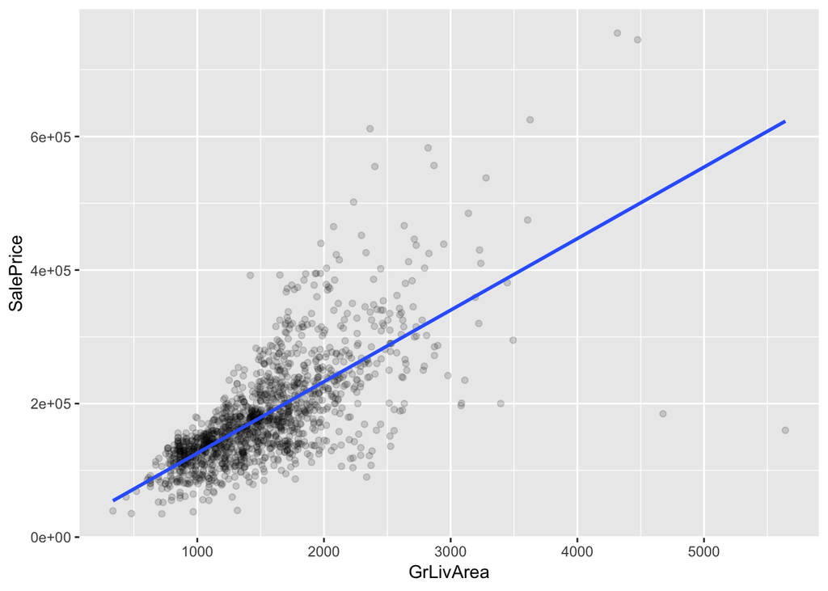

```r
library(tidyverse)
data(train.data)



ggplot(train.data) +
  geom_point(aes(GrLivArea, SalePrice), alpha = .15) +
  geom_smooth(aes(GrLivArea, SalePrice), method = "lm", se = FALSE)
```

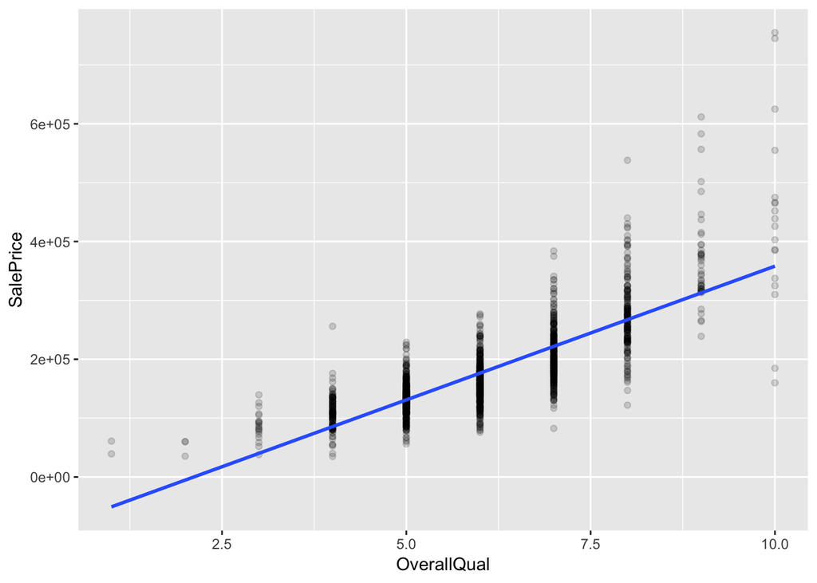

```r
ggplot(train.data) +
  geom_point(aes(OverallQual, SalePrice), alpha = .15) +
  geom_smooth(aes(OverallQual, SalePrice), method = "lm", se = FALSE)
```

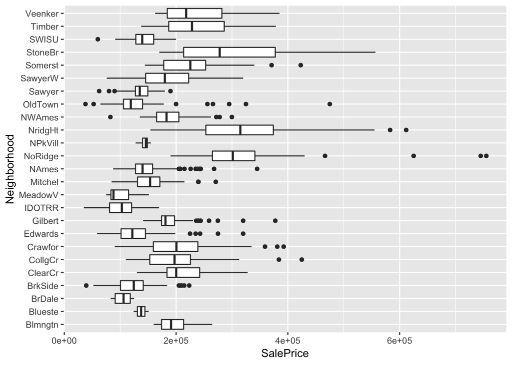

```r
ggplot(train.data) +
  geom_boxplot(aes(Neighborhood, SalePrice)) +
  coord_flip()
```

*1. How would you interpret the coefficients on GrLivArea and OverallQual?*

For every unit of `GrLivArea` increased, the price increases by $55.56. For every unit increase of `OverallQual`, the sale price of the house increases by $20,951.

In other words, the feature of OverallQual holds more weight over price increases than GrLivArea.

```r
train.mult.lm <- lm(formula = SalePrice ~ OverallQual + GrLivArea + Neighborhood, data = train.data)

tidy(train.mult.lm)
```

```
## # A tibble: 27 x 5
##    term                estimate std.error statistic  p.value
##    <chr>                  <dbl>     <dbl>     <dbl>    <dbl>
##  1 (Intercept)         -34829.   11541.       -3.02 2.59e- 3
##  2 OverallQual          20951.    1162.       18.0  1.24e-65
##  3 GrLivArea               55.6      2.50     22.2  2.38e-94
##  4 NeighborhoodBlueste -30753.   27697.       -1.11 2.67e- 1
##  5 NeighborhoodBrDale  -43359.   12979.       -3.34 8.57e- 4
##  6 NeighborhoodBrkSide -13025.   10450.       -1.25 2.13e- 1
##  7 NeighborhoodClearCr  24576.   11570.        2.12 3.38e- 2
##  8 NeighborhoodCollgCr  11414.    9497.        1.20 2.30e- 1
##  9 NeighborhoodCrawfor  14444.   10502.        1.38 1.69e- 1
## 10 NeighborhoodEdwards -17843.    9986.       -1.79 7.42e- 2
## # … with 17 more rows
```

*2. How would you interpret the coefficient on NeighborhoodBrkSide?*

Because it is a negative value, one can assume by the data that the value of the house decreases in value by about $13,025.

*3. Are the features significant?*

*4. Are the features practically significant?*

Again, it would seem that looking at `OverallQual` and `GrLivArea` would be conclusive indicators of correlation given the p value but one would have to comb the neighborhood data more diligently as many of the neighborhoods are not good indicators of sales price.

*5. Is the model a good fit?*

Because the adjusted R squared value is close to 1, the model is a good fit.

```r
glance(train.mult.lm)
```

```
## # A tibble: 1 x 11
##   r.squared adj.r.squared  sigma statistic p.value    df  logLik    AIC
##       <dbl>         <dbl>  <dbl>     <dbl>   <dbl> <int>   <dbl>  <dbl>
## 1     0.787         0.783 37009.      203.       0    27 -17416. 34887.
## # … with 3 more variables: BIC <dbl>, deviance <dbl>, df.residual <int>
```